# Exploratory Data Analysis of Loan Eligibility Data Set

Jake Bersabe

15/11/2021

Import data set and libraries:

```r
library(dplyr)
library(skimr)

data <- readr::read_csv("train.csv")
glimpse(data)
```

```
## Rows: 614
## Columns: 13
## $ Loan_ID           <chr> "LP001002", "LP001003", "LP001005", "LP001006", "LP0~
## $ Gender            <chr> "Male", "Male", "Male", "Male", "Male", "Male", "Mal~
## $ Married           <chr> "No", "Yes", "Yes", "Yes", "No", "Yes", "Yes", "Yes"~
## $ Dependents        <dbl> 0, 1, 0, 0, 0, 2, 0, 3, 2, 1, 2, 2, 2, 0, 2, 0, 1, 0~
## $ Education         <chr> "Graduate", "Graduate", "Graduate", "Not Graduate", ~
## $ Self_Employed     <chr> "No", "No", "Yes", "No", "No", "Yes", "No", "No", "N~
## $ ApplicantIncome   <dbl> 5849, 4583, 3000, 2583, 6000, 5417, 2333, 3036, 4006~
## $ CoapplicantIncome <dbl> 0, 1508, 0, 2358, 0, 4196, 1516, 2504, 1526, 10968, ~
## $ LoanAmount        <dbl> NA, 128, 66, 120, 141, 267, 95, 158, 168, 349, 70, 1~
## $ Loan_Amount_Term  <dbl> 360, 360, 360, 360, 360, 360, 360, 360, 360, 360, 36~
## $ Credit_History    <dbl> 1, 1, 1, 1, 1, 1, 1, 0, 1, 1, 1, 1, 1, 1, 1, 1, NA, ~
## $ Property_Area     <chr> "Urban", "Rural", "Urban", "Urban", "Urban", "Urban"~
## $ Loan_Status       <chr> "Y", "N", "Y", "Y", "Y", "Y", "Y", "N", "Y", "N", "Y~
```

```r
skim(data)
```

Data summary

| Name | data |
| --- | --- |
| Number of rows | 614 |
| Number of columns | 13 |
| _______________________ |  |
| Column type frequency: |  |
| character | 7 |
| numeric | 6 |
| ________________________ |  |
| Group variables | None |

**Variable type: character**

| skim_variable | n_missing | complete_rate | min | max | empty | n_unique | whitespace |
| --- | --- | --- | --- | --- | --- | --- | --- |
| Loan_ID | 0 | 1.00 | 8 | 8 | 0 | 614 | 0 |
| Gender | 13 | 0.98 | 4 | 6 | 0 | 2 | 0 |
| Married | 3 | 1.00 | 2 | 3 | 0 | 2 | 0 |
| Education | 0 | 1.00 | 8 | 12 | 0 | 2 | 0 |
| Self_Employed | 32 | 0.95 | 2 | 3 | 0 | 2 | 0 |
| Property_Area | 0 | 1.00 | 5 | 9 | 0 | 3 | 0 |
| Loan_Status | 0 | 1.00 | 1 | 1 | 0 | 2 | 0 |

**Variable type: numeric**

| skim_variable | n_missing | complete_rate | mean | sd | p0 | p25 | p50 | p75 | p100 | hist |
| --- | --- | --- | --- | --- | --- | --- | --- | --- | --- | --- |
| Dependents | 15 | 0.98 | 0.76 | 1.02 | 0 | 0.0 | 0.0 | 2.00 | 3 | ▇▂▁▂▁ |
| ApplicantIncome | 0 | 1.00 | 5403.46 | 6109.04 | 150 | 2877.5 | 3812.5 | 5795.00 | 81000 | ▇▁▁▁▁ |
| CoapplicantIncome | 0 | 1.00 | 1621.25 | 2926.25 | 0 | 0.0 | 1188.5 | 2297.25 | 41667 | ▇▁▁▁▁ |
| LoanAmount | 22 | 0.96 | 146.41 | 85.59 | 9 | 100.0 | 128.0 | 168.00 | 700 | ▇▃▁▁▁ |
| Loan_Amount_Term | 14 | 0.98 | 342.00 | 65.12 | 12 | 360.0 | 360.0 | 360.00 | 480 | ▁▁▁▇▁ |
| Credit_History | 50 | 0.92 | 0.84 | 0.36 | 0 | 1.0 | 1.0 | 1.00 | 1 | ▂▁▁▁▇ |

```r
# Function to add monthly income column
monthly_payment <- function(loan_amount, loan_amount_term){
  r <- 0.005
  monthly_payment <- (loan_amount/(((1+r)^loan_amount_term)-1))*(((1+r)^loan_amount_term)*r)
  return(monthly_payment)
}

# Pre-processing pipeline

data_preprocessed <- data %>%
  mutate(LoanAmount = LoanAmount*1000,
         CombinedIncome = ApplicantIncome + CoapplicantIncome) %>%
  #select(-ApplicantIncome, -CoapplicantIncome) %>%
  mutate(MonthlyPayment = monthly_payment(LoanAmount, Loan_Amount_Term),
         PaymentIncomeRatio = MonthlyPayment/CombinedIncome)

glimpse(data_preprocessed)
```

```
## Rows: 614
## Columns: 16
## $ Loan_ID            <chr> "LP001002", "LP001003", "LP001005", "LP001006", "LP~
## $ Gender             <chr> "Male", "Male", "Male", "Male", "Male", "Male", "Ma~
## $ Married            <chr> "No", "Yes", "Yes", "Yes", "No", "Yes", "Yes", "Yes~
## $ Dependents         <dbl> 0, 1, 0, 0, 0, 2, 0, 3, 2, 1, 2, 2, 2, 0, 2, 0, 1, ~
## $ Education          <chr> "Graduate", "Graduate", "Graduate", "Not Graduate",~
## $ Self_Employed      <chr> "No", "No", "Yes", "No", "No", "Yes", "No", "No", "~
## $ ApplicantIncome    <dbl> 5849, 4583, 3000, 2583, 6000, 5417, 2333, 3036, 400~
## $ CoapplicantIncome  <dbl> 0, 1508, 0, 2358, 0, 4196, 1516, 2504, 1526, 10968,~
## $ LoanAmount         <dbl> NA, 128000, 66000, 120000, 141000, 267000, 95000, 1~
## $ Loan_Amount_Term   <dbl> 360, 360, 360, 360, 360, 360, 360, 360, 360, 360, 3~
## $ Credit_History     <dbl> 1, 1, 1, 1, 1, 1, 1, 0, 1, 1, 1, 1, 1, 1, 1, 1, NA,~
## $ Property_Area      <chr> "Urban", "Rural", "Urban", "Urban", "Urban", "Urban~
## $ Loan_Status        <chr> "Y", "N", "Y", "Y", "Y", "Y", "Y", "N", "Y", "N", "~
## $ CombinedIncome     <dbl> 5849, 6091, 3000, 4941, 6000, 9613, 3849, 5540, 553~
## $ MonthlyPayment     <dbl> NA, 767.4247, 395.7033, 719.4606, 845.3662, 1600.79~
## $ PaymentIncomeRatio <dbl> NA, 0.12599321, 0.13190112, 0.14561033, 0.14089437,~
```

### 1. Is there a difference between the median income of applicants with approved loan status and applicants with rejected loan status?

```r
data_preprocessed %>%
  group_by(Loan_Status) %>%
  summarise(Count = n(), MedianIncome = median(ApplicantIncome))
```

```
## # A tibble: 2 x 3
##   Loan_Status Count MedianIncome
##   <chr>       <int>        <dbl>
## 1 N             192        3834.
## 2 Y             422        3812.
```

> Surprisingly, *applicants who are ineligible for loan have higher average income* than eligible applicants.

### 2. Do applicants with less payment-to-income ratio more likely to be eligible for loan?

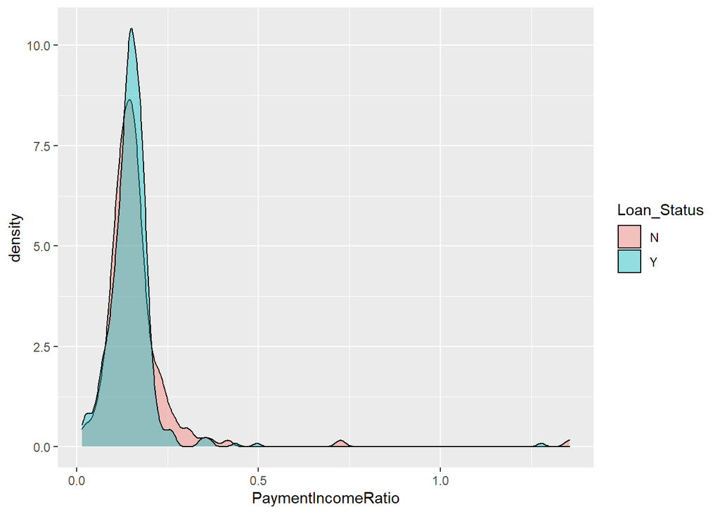

```r
library(ggplot2)
data_preprocessed %>%
  ggplot(aes(PaymentIncomeRatio, fill = Loan_Status))+
  geom_density(alpha  = 0.4)
```

```r
data_preprocessed %>%
  filter(PaymentIncomeRatio != "") %>%
  group_by(Loan_Status) %>%
  summarise(Count = n(), MeanPayIncomeRatio = mean(PaymentIncomeRatio, na.rm=T))
```

```
## # A tibble: 2 x 3
##   Loan_Status Count MeanPayIncomeRatio
##   <chr>       <int>              <dbl>
## 1 N             175              0.162
## 2 Y             403              0.150
```

> Eligible applicants have lower mean of payment-to-income ratio; however, this is not accurate since there are outliers in the data. Median would be the more appropriate measurement to use.

```r
data_preprocessed %>%
  filter(PaymentIncomeRatio != "") %>%
  group_by(Loan_Status) %>%
  summarise(Count = n(), MedianPayIncomeRatio = median(PaymentIncomeRatio, na.rm=T))
```

```
## # A tibble: 2 x 3
##   Loan_Status Count MedianPayIncomeRatio
##   <chr>       <int>                <dbl>
## 1 N             175                0.146
## 2 Y             403                0.149
```

There is not much difference in medians between the two groups.

### 3. Is there a difference in the income of applicants who graduated and those who did not?

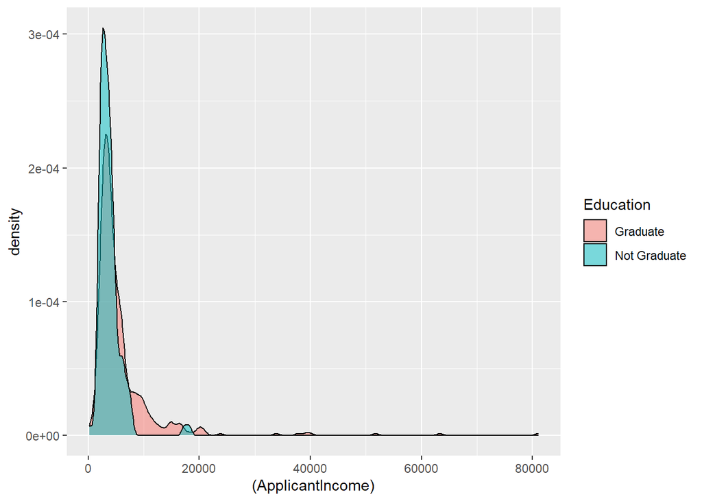

```r
library(ggplot2)

data_preprocessed %>%
  ggplot(aes(x = (ApplicantIncome), fill = Education))+
  geom_density(alpha = 0.5)
```

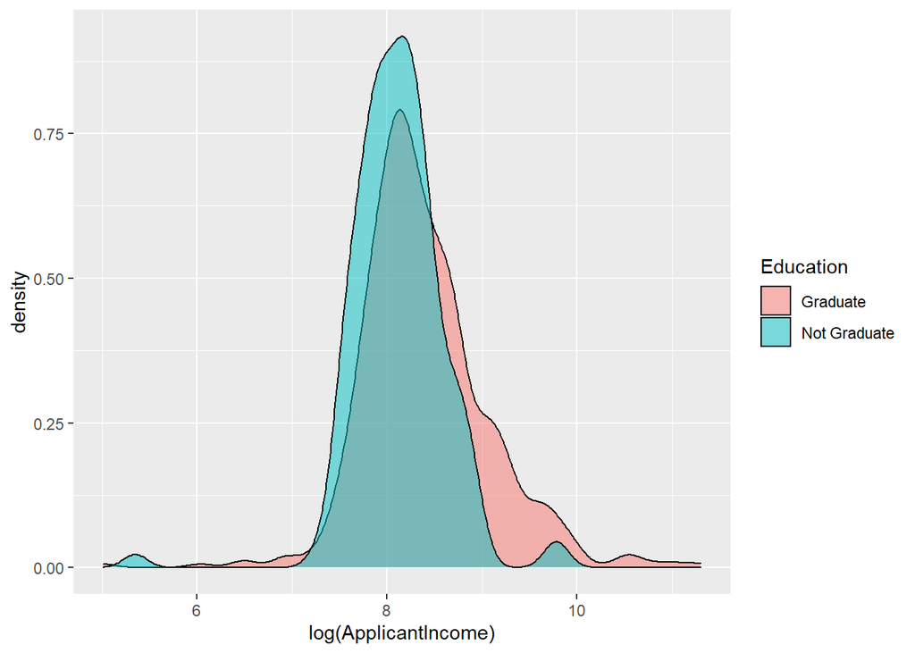

```r
data_preprocessed %>%
  ggplot(aes(x = log(ApplicantIncome), fill = Education))+
  geom_density(alpha = 0.5)
```

> The median for the income of both groups are approximately the same.

### 4. Do self-employed applicants have lower income?

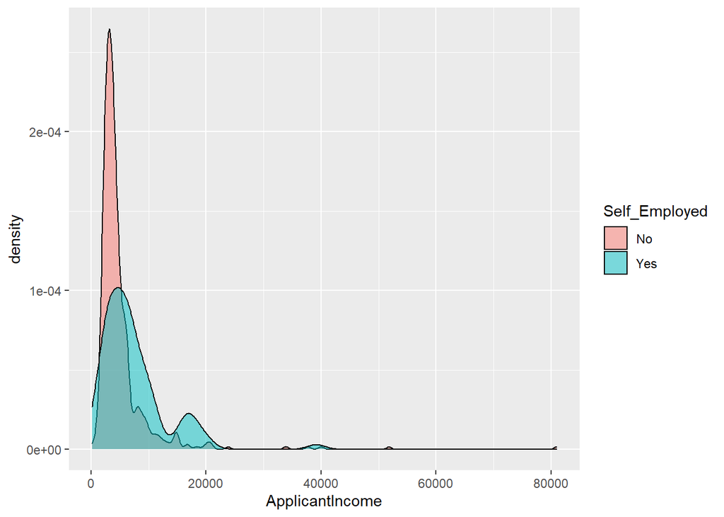

```r
data_preprocessed %>%
  filter(Self_Employed != "") %>%
  ggplot(aes(ApplicantIncome, fill = Self_Employed))+
  geom_density(alpha  = 0.5)
```

```r
data_preprocessed %>%
  filter(Self_Employed != "") %>%
  group_by(Self_Employed) %>%
  summarise(Count = n(), MedianApplicantIncome = median(ApplicantIncome))
```

```
## # A tibble: 2 x 3
##   Self_Employed Count MedianApplicantIncome
##   <chr>         <int>                 <dbl>
## 1 No              500                 3706.
## 2 Yes              82                 5809
```

> Self-employed applicants actually have higher median income.

### 5. Are applicants with low monthly payment more likely to be eligible for loan?

```r
data_preprocessed %>%
  group_by(Loan_Status) %>%
  summarise(Count = n(), MedianMonthlyPayment = median(MonthlyPayment, na.rm = T))
```

```
## # A tibble: 2 x 3
##   Loan_Status Count MedianMonthlyPayment
##   <chr>       <int>                <dbl>
## 1 N             192                 809.
## 2 Y             422                 779.
```

> Eligible applicants have lower median monthly payment.

### 6. Applicants with higher number of dependents have higher income.

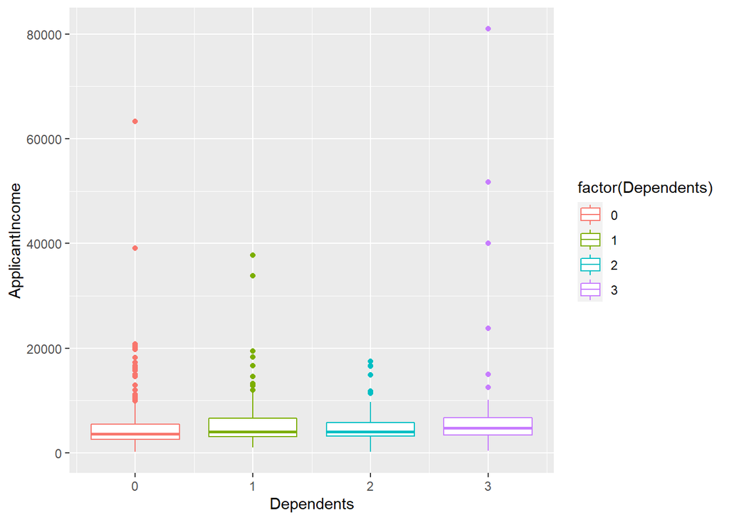

```r
data_preprocessed %>%
  ggplot(aes(y = ApplicantIncome, x = Dependents, color = factor(Dependents)))+
  geom_boxplot()
```

```r
data_preprocessed %>%
  filter(Dependents != "") %>%
  group_by(Dependents) %>%
  summarise(Count = n(), MedianApplicantIncome = median(ApplicantIncome))
```

```
## # A tibble: 4 x 3
##   Dependents Count MedianApplicantIncome
##        <dbl> <int>                 <dbl>
## 1          0   345                 3598
## 2          1   102                 4052.
## 3          2   101                 4006
## 4          3    51                 4691
```

> Applicants with 3 or more dependents have the highest median applicant income.

### 7. How many applicants who are married have dependents?

```r
data_preprocessed %>%
  filter(Married != "" & Dependents != "") %>%
  mutate(Dependents = if_else(Dependents > 0, 1,  0)) %>%
  count(Married, Dependents)
```

```
## # A tibble: 4 x 3
##   Married Dependents     n
##   <chr>        <dbl> <int>
## 1 No               0   171
## 2 No               1    38
## 3 Yes              0   174
## 4 Yes              1   216
```

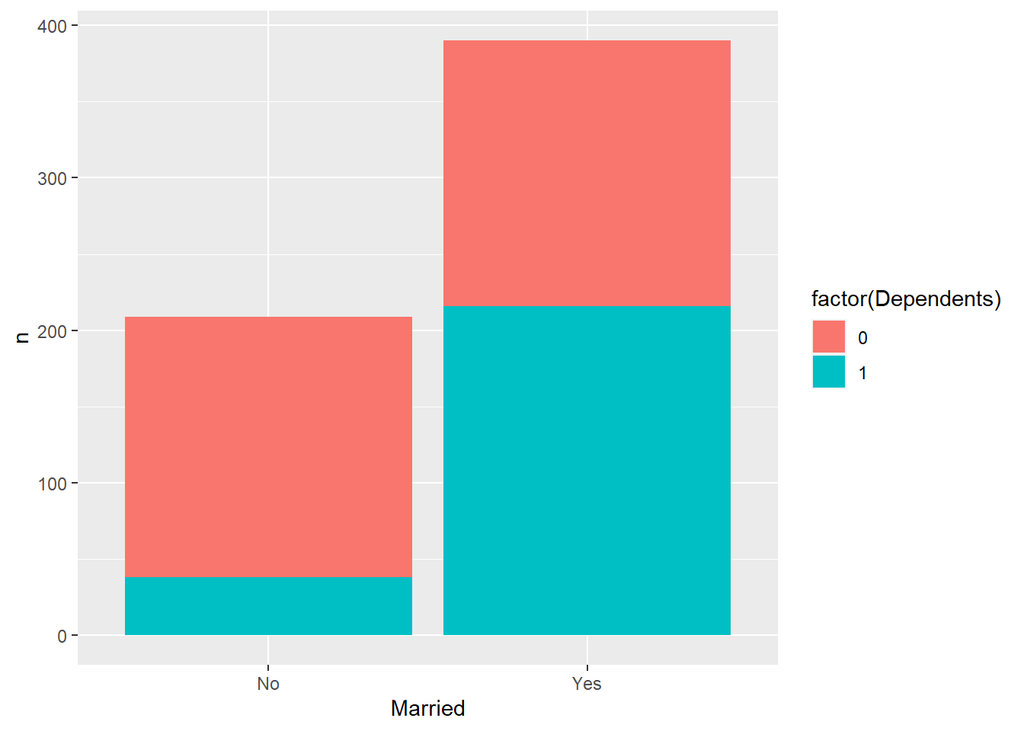

```r
data_preprocessed %>%
  filter(Married != "" & Dependents != "") %>%
  mutate(Dependents = if_else(Dependents > 0, 1,  0)) %>%
  count(Married, Dependents) %>%
  ggplot(aes(x = Married, y = n, fill = factor(Dependents)))+
  geom_col()
```

> Majority of married applicants have dependents; however, married applicants who don’t have dependents still hold a big percentage. Majority of unmarried applicants don’t have dependents.

```r
data_preprocessed %>%
  filter(Married == "No" & Dependents != "") %>%
  mutate(Dependents = if_else(Dependents > 0, 1,  0)) %>%
  count(Married, Dependents) %>%
  mutate(Percentage = n*100/sum(n))
```

```
## # A tibble: 2 x 4
##   Married Dependents     n Percentage
##   <chr>        <dbl> <int>      <dbl>
## 1 No               0   171       81.8
## 2 No               1    38       18.2
```

### 8. Loan Amount and Applicant Income

```r
ApplicantIncomeCluster <- kmeans(data_preprocessed$ApplicantIncome, 3)
data_preprocessed$ApplicantIncomeCluster <- ApplicantIncomeCluster$cluster

data_preprocessed <- data_preprocessed %>%
  mutate(ApplicantIncomeCluster = if_else(ApplicantIncomeCluster == 1, "High Income",
                                          if_else(ApplicantIncomeCluster == 2, "Mid Income", "Low Income"))) %>%
  mutate(ApplicantIncomeCluster = ordered(ApplicantIncomeCluster, levels = c("High Income", "Mid Income", "Low Income")))
```

[figure not shown]

```r
data_preprocessed %>%
  ggplot(aes(y=ApplicantIncome, x=ApplicantIncomeCluster))+
  geom_boxplot(aes(color = ApplicantIncomeCluster))
```

The graph below shows that the kmeans algorithm cleanly clustered the applicants income.

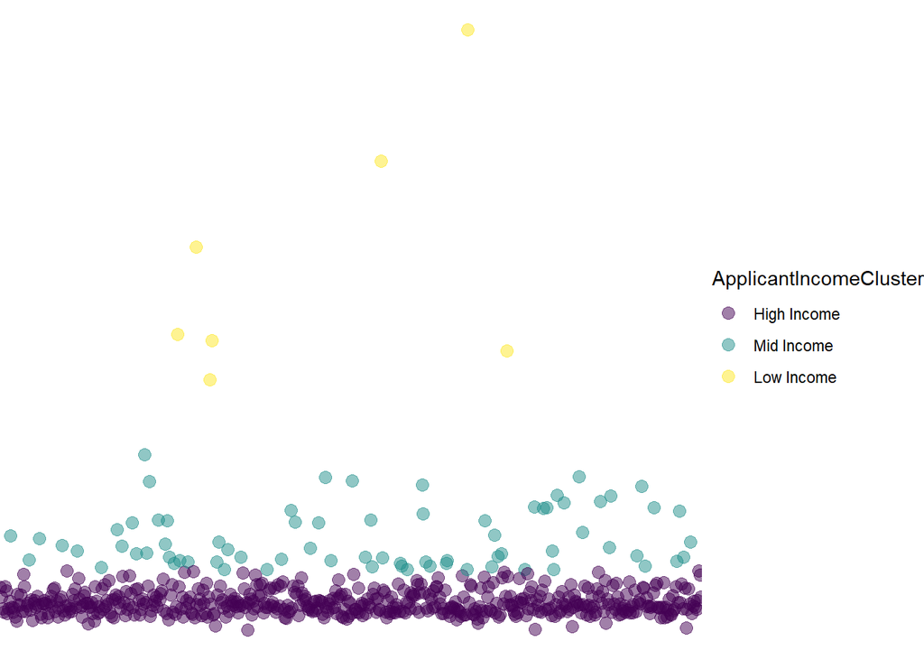

```r
data_preprocessed %>%
  ggplot(aes(x=Loan_ID, y=ApplicantIncome, color = ApplicantIncomeCluster))+
  geom_point(size = 3, alpha = 0.5)+
  theme_void()
```

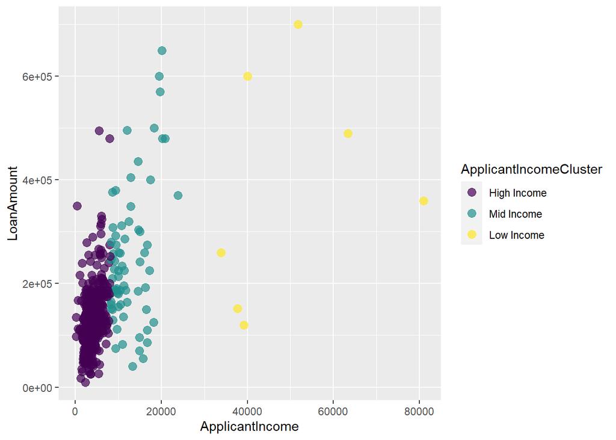

```r
data_preprocessed %>%
  ggplot(aes(x = ApplicantIncome, y = LoanAmount, color=ApplicantIncomeCluster))+
  geom_point(alpha = 0.7, size = 3)
```

> Clusters 2 and 3 of applicant income have greater range of loan amount than cluster 1 applicants.

### 9. Applicants with higher income pay the loan in shorter term

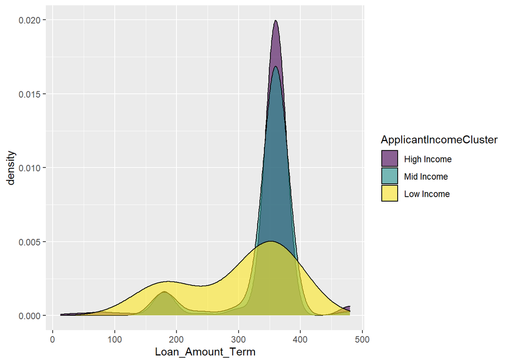

```r
data_preprocessed %>%
  ggplot(aes(Loan_Amount_Term))+
  geom_density(aes(fill = ApplicantIncomeCluster), alpha =  0.6)
```

### 10. Are most of the applicants with zero co-applicant income unmarried?

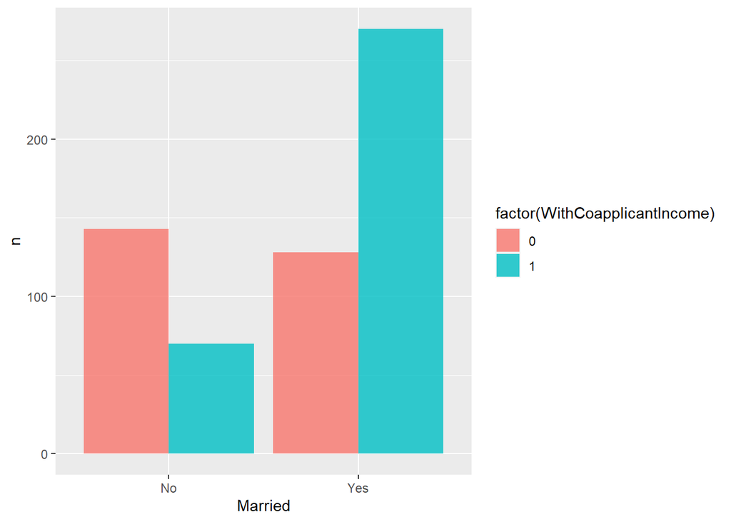

```r
data_preprocessed %>%
  filter(Married != "") %>%
  mutate(WithCoapplicantIncome = if_else(CoapplicantIncome > 0, 1, 0)) %>%
  group_by(Married, WithCoapplicantIncome) %>%
  count() %>%
  ggplot(aes(x = Married, y = n, fill = factor(WithCoapplicantIncome)))+
  geom_col(position = "dodge", alpha = 0.8)
```

> Most married applicants have co-applicant income and most unmarried applicants don’t have co-applicant income.

### 11. Do male applicants have higher income than female applicants?

```r
data_preprocessed %>%
  filter(Gender != "") %>%
  group_by(Gender) %>%
  summarise(Count = n(), median(ApplicantIncome))
```

```
## # A tibble: 2 x 3
##   Gender Count `median(ApplicantIncome)`
##   <chr>  <int>                     <dbl>
## 1 Female   112                      3583
## 2 Male     489                      3865
```

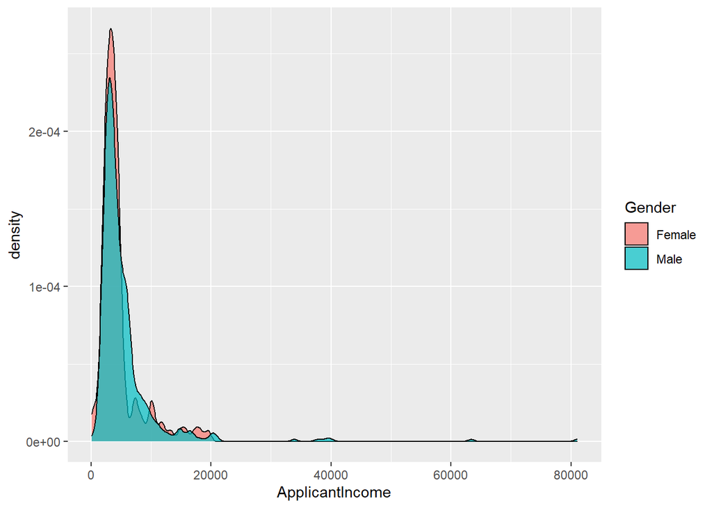

```r
data_preprocessed %>%
  filter(Gender != "") %>%
  ggplot(aes(ApplicantIncome, fill = Gender))+
  geom_density(alpha = 0.7)
```

> Apparently, males have slightly higher income than females.